# FullCode_Additional__Project_AML-1

## Problem Statement

### Business context

Employee Promotion means the ascension of an employee to higher ranks, this aspect of the job is what drives employees the most. The ultimate reward for dedication and loyalty towards an organization and the HR team plays an important role in handling all these promotion tasks based on ratings and other attributes available.

The HR team in JMD company stored data on the promotion cycle last year, which consists of details of all the employees in the company working last year and also if they got promoted or not, but every time this process gets delayed due to so many details available for each employee - it gets difficult to compare and decide.

### Objective

For the upcoming appraisal cycle, the HR team wants to utilize the stored data and leverage machine learning to make a model that will predict if a person is eligible for promotion or not. You, as a data scientist at JMD company, need to come up with the best possible model that will help the HR team to predict if a person is eligible for promotion or not.

### Data Description

- employee_id: Unique ID for the employee
- department: Department of employee
- region: Region of employment (unordered)
- education: Education Level
- gender: Gender of Employee
- recruitment_channel: Channel of recruitment for employee
- no *of* trainings: no of other training completed in the previous year on soft skills, technical skills, etc.
- age: Age of Employee
- previous *year* rating: Employee Rating for the previous year
- length *of* service: Length of service in years
- awards_ won: if awards won during the previous year then 1 else 0
- avg *training* score: Average score in current training evaluations
- is_promoted: (Target) Recommended for promotion

## Importing necessary libraries

```python
# Installing the libraries with the specified version.
# uncomment and run the following line if Google Colab is being used
!pip install scikit-learn==1.2.2 seaborn==0.13.1 matplotlib==3.7.1 numpy==1.26.0 pandas==2.1.4 imbalanced-learn==0.10.1 xgboost==2.0.3 -q --user
```

```python
# Installing the libraries with the specified version.
# uncomment and run the following lines if Jupyter Notebook is being used
# !pip install scikit-learn==1.2.2 seaborn==0.13.1 matplotlib==3.7.1 numpy==1.25.2 pandas==1.5.3 imbalanced-learn==0.10.1 xgboost==2.0.3 -q --user
# !pip install --upgrade -q threadpoolctl
```

```python
# This will help in making the Python code more structured automatically (good coding practice)
# %load_ext nb_black

# Libraries to help with reading and manipulating data
import pandas as pd
import numpy as np

# Libaries to help with data visualization
import matplotlib.pyplot as plt
import seaborn as sns

# To tune model, get different metric scores, and split data
from sklearn.metrics import (
    f1_score,
    accuracy_score,
    recall_score,
    precision_score,
    confusion_matrix,
    roc_auc_score,
    ConfusionMatrixDisplay,
)
from sklearn.model_selection import train_test_split, StratifiedKFold, cross_val_score

# To be used for data scaling and one hot encoding
from sklearn.preprocessing import StandardScaler, MinMaxScaler, OneHotEncoder

# To impute missing values
from sklearn.impute import SimpleImputer
from sklearn import metrics

# To oversample and undersample data
from imblearn.over_sampling import SMOTE
from imblearn.under_sampling import RandomUnderSampler

# To do hyperparameter tuning
from sklearn.model_selection import RandomizedSearchCV

# To define maximum number of columns to be displayed in a dataframe
pd.set_option("display.max_columns", None)

# To supress scientific notations for a dataframe
pd.set_option("display.float_format", lambda x: "%.3f" % x)

# To help with model building
from sklearn.tree import DecisionTreeClassifier
from sklearn.ensemble import (
    AdaBoostClassifier,
    GradientBoostingClassifier,
    RandomForestClassifier,
    BaggingClassifier,
)
from xgboost import XGBClassifier
from sklearn.linear_model import LogisticRegression

# To suppress scientific notations
pd.set_option("display.float_format", lambda x: "%.3f" % x)

# To supress warnings
import warnings

warnings.filterwarnings("ignore")
```

## Loading the dataset

```python
# Connecting Google drive
from google.colab import drive
drive.mount('/content/drive')
```

```python
# Loading the data from the source csv located in Google drive into a dataframe
data = pd.read_csv('/content/drive/MyDrive/PGP-AIML/Advance Machine Learning/Project-2/employee_promotion.csv')
```

```python
# Keeping a copy of the original data.
data_bkp = data.copy()
```

## Data Overview

### Checking the shape of the dataset

```python
# checking shape of the data
print(f"There are {data.shape[0]} rows and {data.shape[1]} columns.")
```

```
There are 54808 rows and 13 columns.
```

### Displaying the first few rows of the dataset

```python
# let's view the first 5 rows of the data
data.head()
```

|  | employee_id | department | region | education | gender | recruitment_channel | no_of_trainings | age | previous_year_rating | length_of_service | awards_won | avg_training_score | is_promoted |
| --- | --- | --- | --- | --- | --- | --- | --- | --- | --- | --- | --- | --- | --- |
| 0 | 65438 | Sales & Marketing | region_7 | Master's & above | f | sourcing | 1 | 35 | 5.000 | 8 | 0 | 49.000 | 0 |
| 1 | 65141 | Operations | region_22 | Bachelor's | m | other | 1 | 30 | 5.000 | 4 | 0 | 60.000 | 0 |
| 2 | 7513 | Sales & Marketing | region_19 | Bachelor's | m | sourcing | 1 | 34 | 3.000 | 7 | 0 | 50.000 | 0 |
| 3 | 2542 | Sales & Marketing | region_23 | Bachelor's | m | other | 2 | 39 | 1.000 | 10 | 0 | 50.000 | 0 |
| 4 | 48945 | Technology | region_26 | Bachelor's | m | other | 1 | 45 | 3.000 | 2 | 0 | 73.000 | 0 |

### Displaying the last few rows of the dataset

```python
# let's view the last 5 rows of the data
data.tail()
```

|  | employee_id | department | region | education | gender | recruitment_channel | no_of_trainings | age | previous_year_rating | length_of_service | awards_won | avg_training_score | is_promoted |
| --- | --- | --- | --- | --- | --- | --- | --- | --- | --- | --- | --- | --- | --- |
| 54803 | 3030 | Technology | region_14 | Bachelor's | m | sourcing | 1 | 48 | 3.000 | 17 | 0 | 78.000 | 0 |
| 54804 | 74592 | Operations | region_27 | Master's & above | f | other | 1 | 37 | 2.000 | 6 | 0 | 56.000 | 0 |
| 54805 | 13918 | Analytics | region_1 | Bachelor's | m | other | 1 | 27 | 5.000 | 3 | 0 | 79.000 | 0 |
| 54806 | 13614 | Sales & Marketing | region_9 | NaN | m | sourcing | 1 | 29 | 1.000 | 2 | 0 | NaN | 0 |
| 54807 | 51526 | HR | region_22 | Bachelor's | m | other | 1 | 27 | 1.000 | 5 | 0 | 49.000 | 0 |

### Checking the data types of the columns for the dataset

```python
# let's check the data types of the columns in the dataset
data.info()
```

```
<class 'pandas.core.frame.DataFrame'>
RangeIndex: 54808 entries, 0 to 54807
Data columns (total 13 columns):
 #   Column                Non-Null Count  Dtype
---  ------                --------------  -----
 0   employee_id           54808 non-null  int64
 1   department            54808 non-null  object
 2   region                54808 non-null  object
 3   education             52399 non-null  object
 4   gender                54808 non-null  object
 5   recruitment_channel   54808 non-null  object
 6   no_of_trainings       54808 non-null  int64
 7   age                   54808 non-null  int64
 8   previous_year_rating  50684 non-null  float64
 9   length_of_service     54808 non-null  int64
 10  awards_won            54808 non-null  int64
 11  avg_training_score    52248 non-null  float64
 12  is_promoted           54808 non-null  int64
dtypes: float64(2), int64(6), object(5)
memory usage: 5.4+ MB
```

- Only 5 variables are object type rest all are numerical types.
- 3 columns have less than 54808 non-null values i.e. columns have missing values.

### Checking for duplicate values

```python
# let's check for duplicate values in the data
data.duplicated().sum()
```

```
0
```

### Checking for missing values

```python
# let's check for missing values in the data
round(data.isnull().sum() / data.isnull().count() * 100, 2)
```

|  | 0 |
| --- | --- |
| employee_id | 0.000 |
| department | 0.000 |
| region | 0.000 |
| education | 4.400 |
| gender | 0.000 |
| recruitment_channel | 0.000 |
| no_of_trainings | 0.000 |
| age | 0.000 |
| previous_year_rating | 7.520 |
| length_of_service | 0.000 |
| awards_won | 0.000 |
| avg_training_score | 4.670 |
| is_promoted | 0.000 |

**dtype:** float64

**Observations**

- `education` column has 4.4% missing values out of the total observations.
- `previous_year_rating` column has 7.52% missing values out of the total observations.
- `avg_training_score` column has 4.67% missing values out of the total observations.

### Statistical summary of the dataset

```python
# let's view the statistical summary of the numerical columns in the data
data.describe().T
```

|  | count | mean | std | min | 25% | 50% | 75% | max |
| --- | --- | --- | --- | --- | --- | --- | --- | --- |
| employee_id | 54808.000 | 39195.831 | 22586.581 | 1.000 | 19669.750 | 39225.500 | 58730.500 | 78298.000 |
| no_of_trainings | 54808.000 | 1.253 | 0.609 | 1.000 | 1.000 | 1.000 | 1.000 | 10.000 |
| age | 54808.000 | 34.804 | 7.660 | 20.000 | 29.000 | 33.000 | 39.000 | 60.000 |
| previous_year_rating | 50684.000 | 3.329 | 1.260 | 1.000 | 3.000 | 3.000 | 4.000 | 5.000 |
| length_of_service | 54808.000 | 5.866 | 4.265 | 1.000 | 3.000 | 5.000 | 7.000 | 37.000 |
| awards_won | 54808.000 | 0.023 | 0.150 | 0.000 | 0.000 | 0.000 | 0.000 | 1.000 |
| avg_training_score | 52248.000 | 63.712 | 13.522 | 39.000 | 51.000 | 60.000 | 77.000 | 99.000 |
| is_promoted | 54808.000 | 0.085 | 0.279 | 0.000 | 0.000 | 0.000 | 0.000 | 1.000 |

```python
data.describe(include=["object"]).T
```

|  | count | unique | top | freq |
| --- | --- | --- | --- | --- |
| department | 54808 | 9 | Sales & Marketing | 16840 |
| region | 54808 | 34 | region_2 | 12343 |
| education | 52399 | 3 | Bachelor's | 36669 |
| gender | 54808 | 2 | m | 38496 |
| recruitment_channel | 54808 | 3 | other | 30446 |

```python
data["is_promoted"].value_counts(1)
```

| is_promoted | proportion |
| --- | --- |
| 0 | 0.915 |
| 1 | 0.085 |

**dtype:** float64

**Observations**

**Let's check the number of unique values in each column including Null**

```python
# Show unique values in each column including object type columns
for i in data.columns:
    print("Unique values including null in", i, "are (normalized): ")
    print("-" * 50)
    print(data[i].value_counts(normalize=True, dropna=False))
    print("\n")
```

```
Unique values including null in employee_id are (normalized):
--------------------------------------------------
employee_id
65438   0.000
16223   0.000
38250   0.000
68086   0.000
78080   0.000
         ...
38645   0.000
76563   0.000
46788   0.000
75029   0.000
51526   0.000
Name: proportion, Length: 54808, dtype: float64


Unique values including null in department are (normalized):
--------------------------------------------------
department
Sales & Marketing   0.307
Operations          0.207
Technology          0.130
Procurement         0.130
Analytics           0.098
Finance             0.046
HR                  0.044
Legal               0.019
R&D                 0.018
Name: proportion, dtype: float64


Unique values including null in region are (normalized):
--------------------------------------------------
region
region_2    0.225
region_22   0.117
region_7    0.088
region_15   0.051
region_13   0.048
```

[output cut: 240 more lines]

```
95.000   0.001
98.000   0.001
99.000   0.001
41.000   0.000
40.000   0.000
39.000   0.000
Name: proportion, dtype: float64


Unique values including null in is_promoted are (normalized):
--------------------------------------------------
is_promoted
0   0.915
1   0.085
Name: proportion, dtype: float64
```

```python
# ID column consists of uniques ID for emloyees and hence will not add value to the modeling
data.drop(columns="employee_id", inplace=True)
```

**Observations**

## Exploratory Data Analysis (EDA)

- EDA is an important part of any project involving data.
- It is important to investigate and understand the data better before building a model with it.
- A few questions have been mentioned below which will help you approach the analysis in the right manner and generate insights from the data.
- A thorough analysis of the data, in addition to the questions mentioned below, should be done.

**Questions**:

1. How is the distribution of average training score of employee ?
2. How is the distribution age of employee ?
3. How does the change in length of service (`length_of_service`) vary by the employee's promotion status (`is_promoted`)?
4. How does the previous rating(`previous_year_rating`) vary by the employee's promotion status (`is_promoted`)?
5. What are the attributes that have a strong correlation with each other?

#### The below functions need to be defined to carry out the Exploratory Data Analysis.

```python
# function to plot a boxplot and a histogram along the same scale.


def histogram_boxplot(data, feature, figsize=(12, 7), kde=False, bins=None):
    """
    Boxplot and histogram combined

    data: dataframe
    feature: dataframe column
    figsize: size of figure (default (12,7))
    kde: whether to the show density curve (default False)
    bins: number of bins for histogram (default None)
    """
    f2, (ax_box2, ax_hist2) = plt.subplots(
        nrows=2,  # Number of rows of the subplot grid= 2
        sharex=True,  # x-axis will be shared among all subplots
        gridspec_kw={"height_ratios": (0.25, 0.75)},
        figsize=figsize,
    )  # creating the 2 subplots
    sns.boxplot(
        data=data, x=feature, ax=ax_box2, showmeans=True, color="violet"
    )  # boxplot will be created and a triangle will indicate the mean value of the column
    sns.histplot(
        data=data, x=feature, kde=kde, ax=ax_hist2, bins=bins, palette="winter"
    ) if bins else sns.histplot(
        data=data, x=feature, kde=kde, ax=ax_hist2
    )  # For histogram
    ax_hist2.axvline(
        data[feature].mean(), color="green", linestyle="--"
    )  # Add mean to the histogram
    ax_hist2.axvline(
        data[feature].median(), color="black", linestyle="-"
    )  # Add median to the histogram
```

```python
# function to create labeled barplots


def labeled_barplot(data, feature, perc=True, n=None):
    """
    Barplot with percentage at the top

    data: dataframe
    feature: dataframe column
    perc: whether to display percentages instead of count (default is False)
    n: displays the top n category levels (default is None, i.e., display all levels)
    """

    total = len(data[feature])  # length of the column§
    count = data[feature].nunique()
    if n is None:
        plt.figure(figsize=(count + 1, 5))
    else:
        plt.figure(figsize=(n + 1, 5))

    plt.xticks(rotation=90, fontsize=15)
    ax = sns.countplot(
        data=data,
        x=feature,
        palette="Paired",
        order=data[feature].value_counts().index[:n].sort_values(),
    )

    for p in ax.patches:
        if perc == True:
            label = "{:.1f}%".format(
                100 * p.get_height() / total
            )  # percentage of each class of the category
        else:
            label = p.get_height()  # count of each level of the category

        x = p.get_x() + p.get_width() / 2  # width of the plot
        y = p.get_height()  # height of the plot

        ax.annotate(
            label,
            (x, y),
            ha="center",
            va="center",
            size=12,
            xytext=(0, 5),
            textcoords="offset points",
        )  # annotate the percentage

    plt.show()  # show the plot
```

```python
# function to plot stacked bar chart

def stacked_barplot(data, predictor, target):
    """
    Print the category counts and plot a stacked bar chart

    data: dataframe
    predictor: independent variable
    target: target variable
    """
    count = data[predictor].nunique()
    sorter = data[target].value_counts().index[-1]
    tab1 = pd.crosstab(data[predictor], data[target], margins=True).sort_values(
        by=sorter, ascending=False
    )
    print(tab1)
    print("-" * 120)
    tab = pd.crosstab(data[predictor], data[target], normalize="index").sort_values(
        by=sorter, ascending=False
    )
    tab.plot(kind="bar", stacked=True, figsize=(count + 1, 5))
    plt.legend(
        loc="lower left", frameon=False,
    )
    plt.legend(loc="upper left", bbox_to_anchor=(1, 1))
    plt.show()
```

```python
### Function to plot distributions

def distribution_plot_wrt_target(data, predictor, target):

    fig, axs = plt.subplots(2, 2, figsize=(12, 10))

    target_uniq = data[target].unique()

    axs[0, 0].set_title("Distribution of target for target=" + str(target_uniq[0]))
    sns.histplot(
        data=data[data[target] == target_uniq[0]],
        x=predictor,
        kde=True,
        ax=axs[0, 0],
        color="teal",
    )

    axs[0, 1].set_title("Distribution of target for target=" + str(target_uniq[1]))
    sns.histplot(
        data=data[data[target] == target_uniq[1]],
        x=predictor,
        kde=True,
        ax=axs[0, 1],
        color="orange",
    )

    axs[1, 0].set_title("Boxplot w.r.t target")
    sns.boxplot(data=data, x=target, y=predictor, ax=axs[1, 0], palette="gist_rainbow")

    axs[1, 1].set_title("Boxplot (without outliers) w.r.t target")
    sns.boxplot(
        data=data,
        x=target,
        y=predictor,
        ax=axs[1, 1],
        showfliers=False,
        palette="gist_rainbow",
    )

    plt.tight_layout()
    plt.show()
```

### Univariate analysis

#### Observations on No. of Trainings

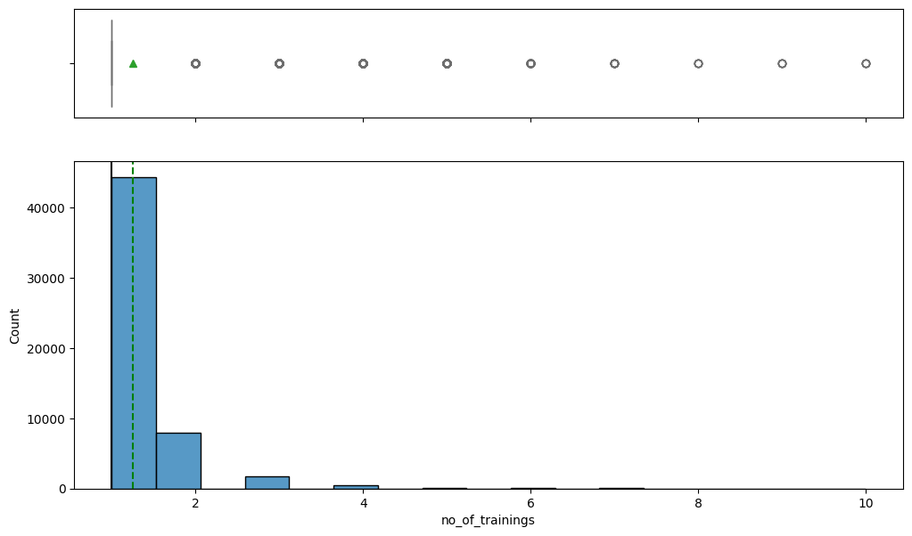

```python
histogram_boxplot(data, "no_of_trainings")
```

**Observations**

- Though the histogram distribution of `no_of_trainings` shows the mean is about 1.25, the box plot shows that the first quartile (Q1) and the third quartile (Q3) seem to overlap around 1. Which means, majority of employees have done only 1 training.

#### Observations on Age

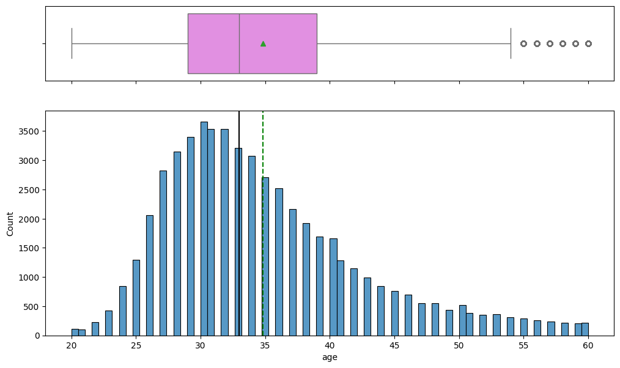

```python
histogram_boxplot(data,'age')
```

**Observations**

#### Observations on Length of Service

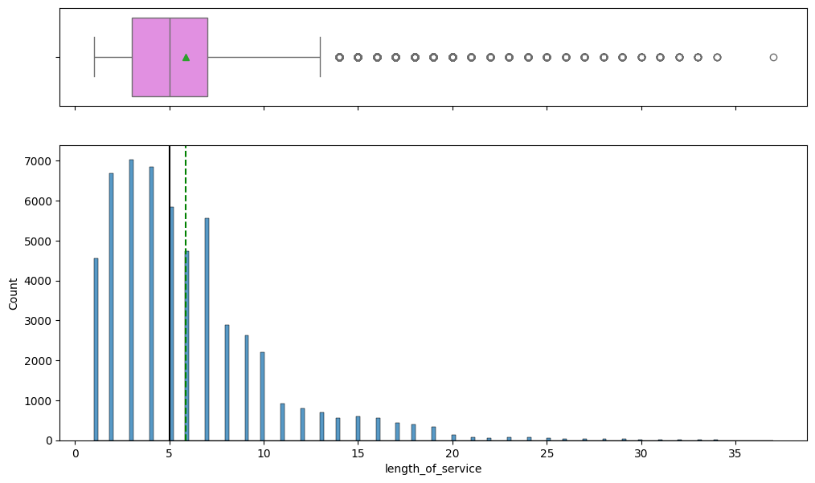

```python
histogram_boxplot(data, 'length_of_service')
```

#### Observations on Average Training Score

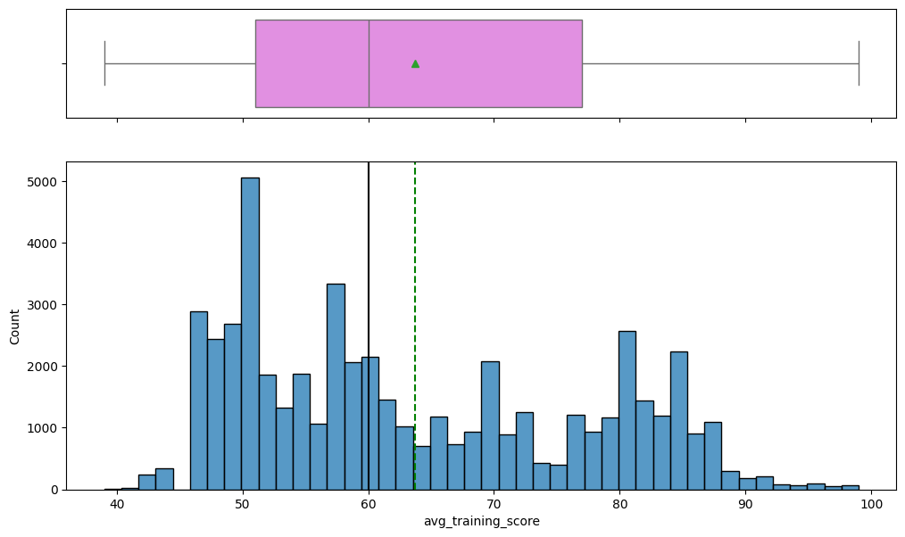

```python
histogram_boxplot(data, 'avg_training_score')
```

**Observations**

- The distribution of `avg_training_score` is also slightly right skewed, with the peak around 50, and the mean being around 63.7
- Minimum score of employees is 39, and maximum score is 99.
- We don't seem to have any outliers.

#### Observations on Department

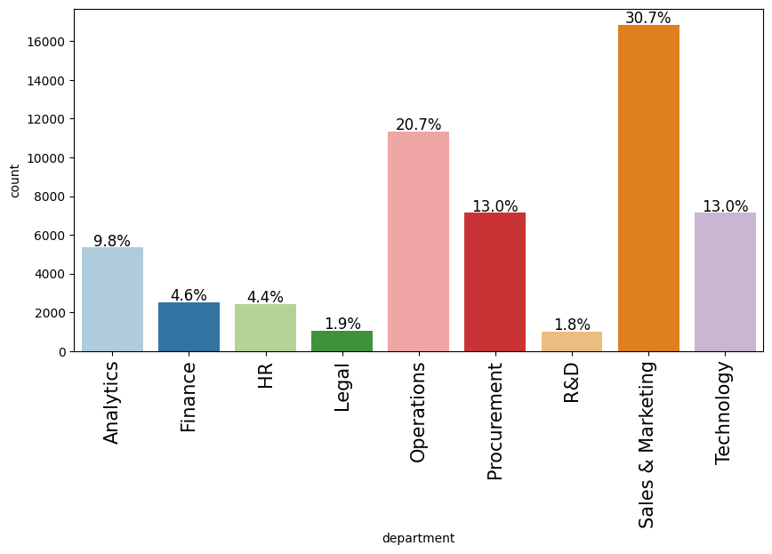

```python
labeled_barplot(data, "department")
```

#### Observations on Education

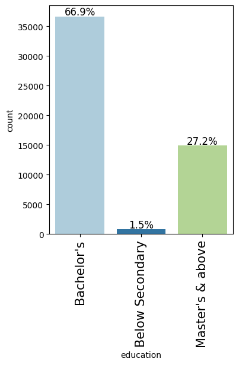

```python
labeled_barplot(data, "education")
```

#### Observations on Gender

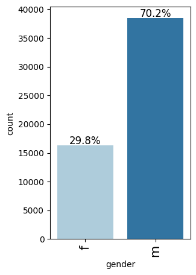

```python
labeled_barplot(data, "gender")
```

#### Observations on Recruitment Channel

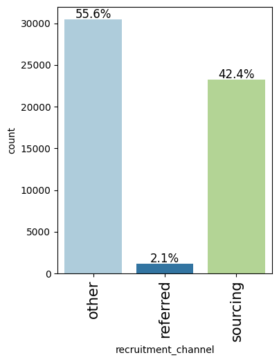

```python
labeled_barplot(data, "recruitment_channel")
```

#### Observations on Previous Year Rating

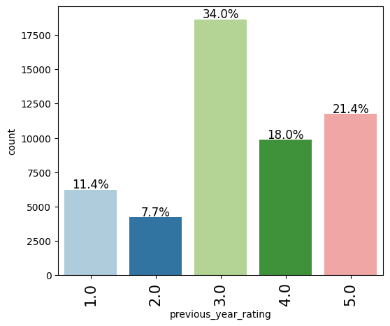

```python
labeled_barplot(data, "previous_year_rating")
```

#### Observations on Awards Won

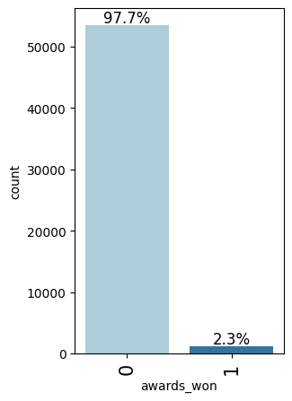

```python
labeled_barplot(data, "awards_won")
```

#### Observations on Region

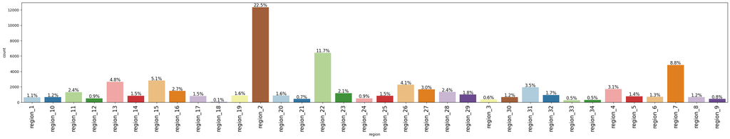

```python
labeled_barplot(data, "region")
```

#### Observations on target variable

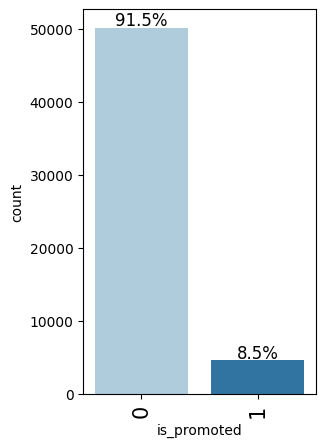

```python
labeled_barplot(data, "is_promoted")
```

### Bivariate Analysis

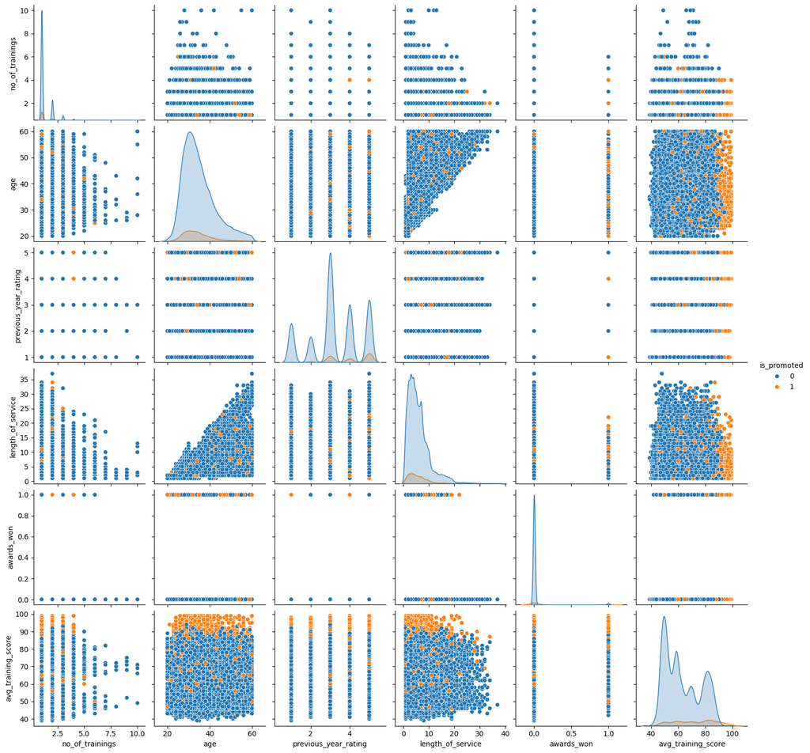

```python
sns.pairplot(data, hue="is_promoted")
```

#### Target variable vs Age

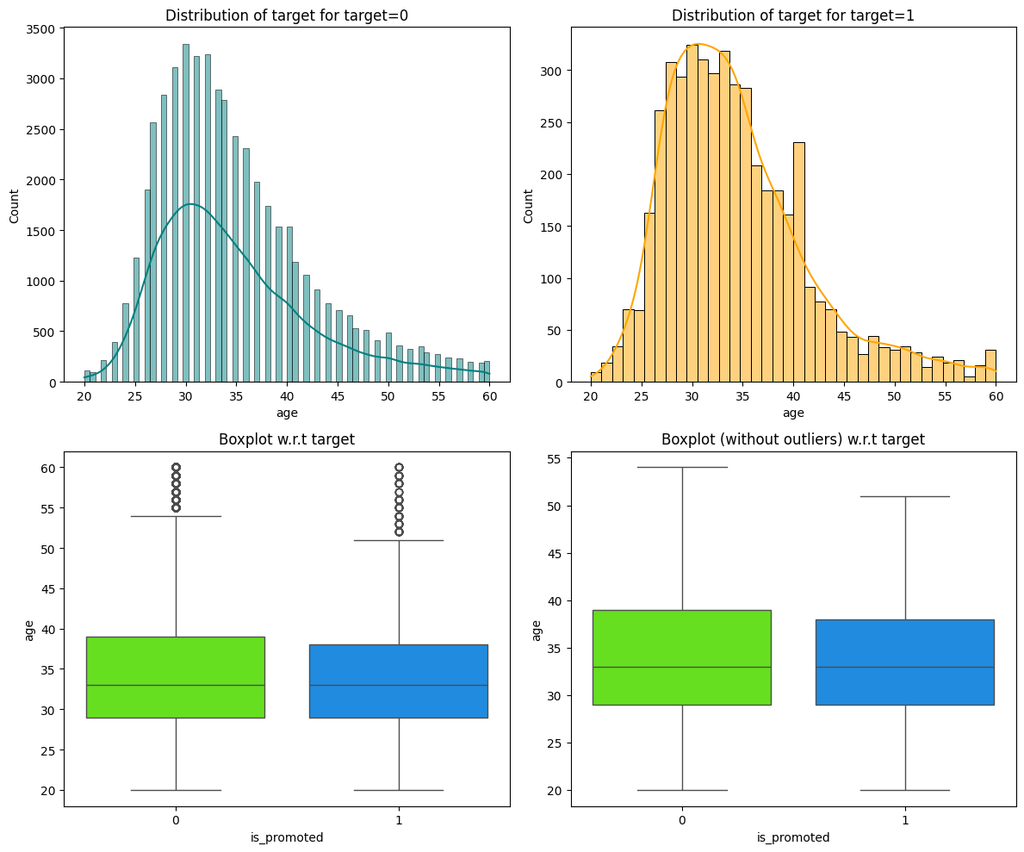

```python
distribution_plot_wrt_target(data, "age", "is_promoted")
```

#### Target variable vs Length of Service

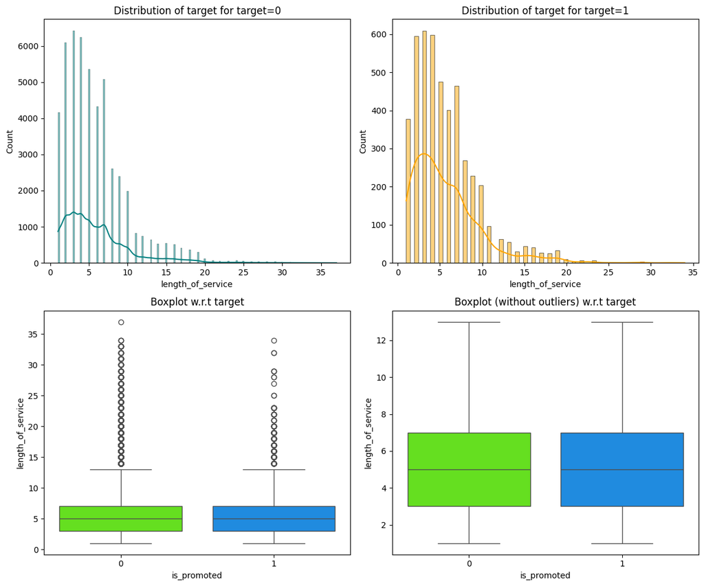

```python
distribution_plot_wrt_target(data, "length_of_service", "is_promoted")
```

**Observations**

- Looking at the data and the distribution plots, it seems that the `length_of_service` has minimal impact on the promotion status.

#### Target variable vs Average Training Score

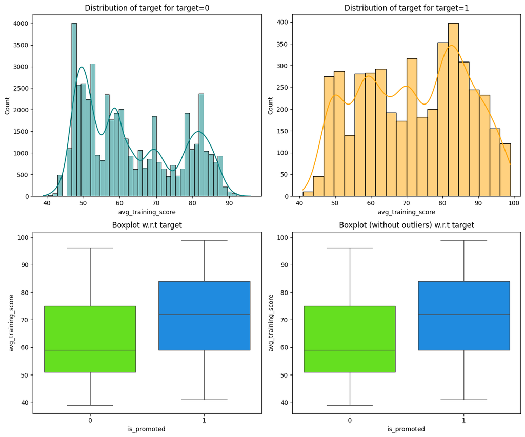

```python
distribution_plot_wrt_target(data, "avg_training_score", "is_promoted")
```

#### Target variable vs Department

```
is_promoted            0     1    All
department
All                50140  4668  54808
Sales & Marketing  15627  1213  16840
Operations         10325  1023  11348
Technology          6370   768   7138
Procurement         6450   688   7138
Analytics           4840   512   5352
Finance             2330   206   2536
HR                  2282   136   2418
R&D                  930    69    999
Legal                986    53   1039
------------------------------------------------------------------------------------------------------------------------
```

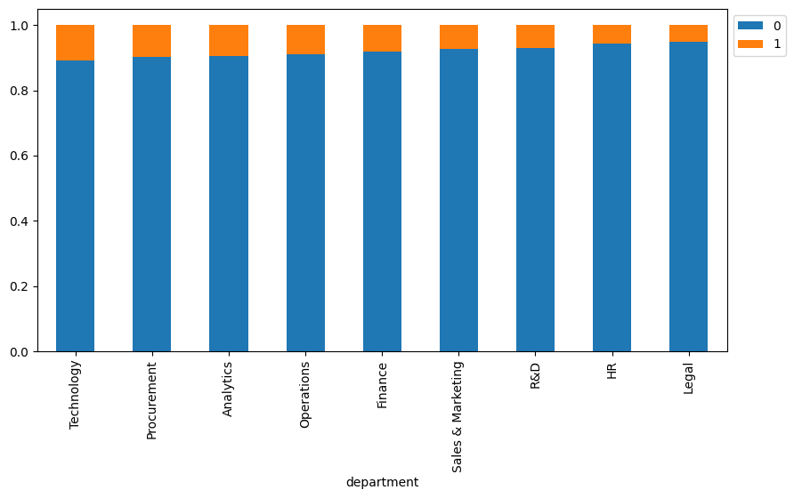

```python
stacked_barplot(data, "department", "is_promoted")
```

#### Target variable vs Region

```
is_promoted      0     1    All
region
All          50140  4668  54808
region_2     11354   989  12343
region_22     5694   734   6428
region_7      4327   516   4843
region_4      1457   246   1703
region_13     2418   230   2648
region_15     2586   222   2808
region_28     1164   154   1318
region_26     2117   143   2260
region_23     1038   137   1175
region_27     1528   131   1659
region_31     1825   110   1935
region_17      687   109    796
region_25      716   103    819
region_16     1363   102   1465
region_11     1241    74   1315
region_14      765    62    827
region_30      598    59    657
region_1       552    58    610
region_19      821    53    874
region_8       602    53    655
region_10      597    51    648
region_20      801    49    850
region_29      951    43    994
region_32      905    40    945
region_3       309    37    346
region_5       731    35    766
region_12      467    33    500
region_6       658    32    690
region_24      490    18    508
region_21      393    18    411
region_33      259    10    269
region_34      284     8    292
region_9       412     8    420
region_18       30     1     31
------------------------------------------------------------------------------------------------------------------------
```

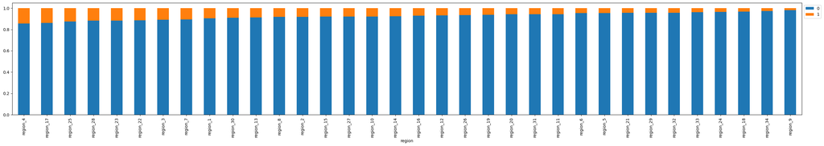

```python
stacked_barplot(data, "region", "is_promoted")
```

#### Target variable vs Education

```
is_promoted           0     1    All
education
All               47853  4546  52399
Bachelor's        33661  3008  36669
Master's & above  13454  1471  14925
Below Secondary     738    67    805
------------------------------------------------------------------------------------------------------------------------
```

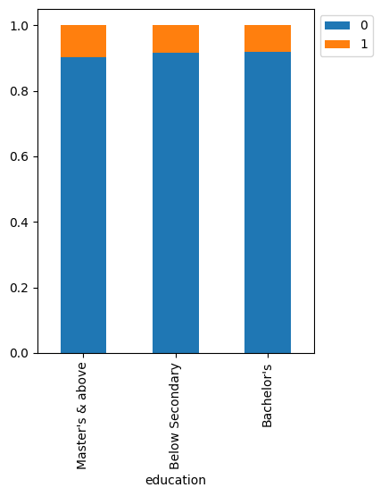

```python
stacked_barplot(data, "education", "is_promoted")
```

#### Target variable vs Gender

```
is_promoted      0     1    All
gender
All          50140  4668  54808
m            35295  3201  38496
f            14845  1467  16312
------------------------------------------------------------------------------------------------------------------------
```

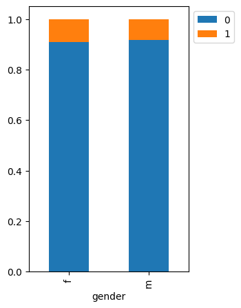

```python
stacked_barplot(data, "gender", "is_promoted")
```

#### Target variable vs Recruitment Channel

```
is_promoted              0     1    All
recruitment_channel
All                  50140  4668  54808
other                27890  2556  30446
sourcing             21246  1974  23220
referred              1004   138   1142
------------------------------------------------------------------------------------------------------------------------
```

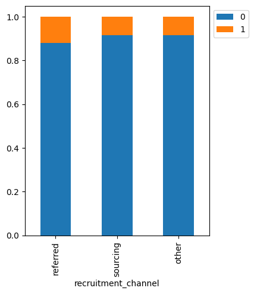

```python
stacked_barplot(data, "recruitment_channel", "is_promoted")
```

#### Target variable vs Previous Year Rating

```
is_promoted               0     1    All
previous_year_rating
All                   46355  4329  50684
5.0                    9820  1921  11741
3.0                   17263  1355  18618
4.0                    9093   784   9877
2.0                    4044   181   4225
1.0                    6135    88   6223
------------------------------------------------------------------------------------------------------------------------
```

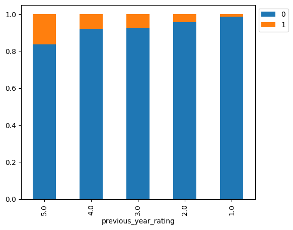

```python
stacked_barplot(data, "previous_year_rating", "is_promoted")
```

**Observations**

- `previous_year_rating` seems to have good degree of positive impact on the promotion status.
- Higher the `previous_year_rating`, better are the chances of promotion.

#### Target variable vs Awards Won

```
is_promoted      0     1    All
awards_won
All          50140  4668  54808
0            49429  4109  53538
1              711   559   1270
------------------------------------------------------------------------------------------------------------------------
```

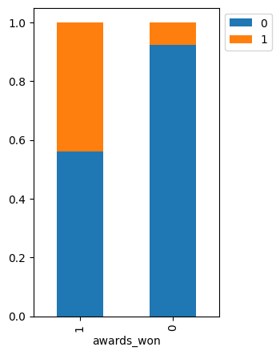

```python
stacked_barplot(data, "awards_won", "is_promoted")
```

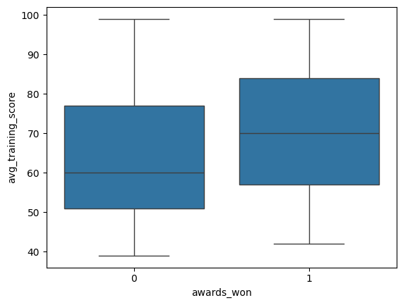

```python
sns.boxplot(data=data, x="awards_won", y="avg_training_score")
```

### Correlation Heatmap

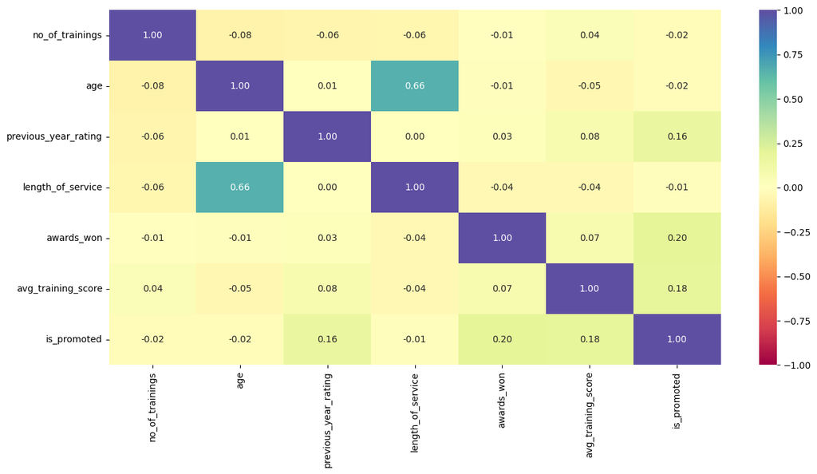

```python
plt.figure(figsize=(15, 7))
sns.heatmap(data.select_dtypes(include=["number"]).corr(), annot=True, vmin=-1, vmax=1, fmt=".2f", cmap="Spectral")
plt.show()
```

*Observations:*

**1) How is the distribution of average training score of employee?**

- The distribution of `avg_training_score` is slightly right skewed, with the peak around 50, and the mean being around 63.7
- Minimum score of employees is 39, and maximum score is 99.
- We don't seem to have any outliers.

**2) How is the distribution age of employee?**

**3) How does the change in length of service (length_of_service) vary by the employee's promotion status (is_promoted)?**

- Looking at the data and the distribution plots, it seems that the `length_of_service` has minimal impact on the promotion status.

**4) How does the previous rating(previous_year_rating) vary by the employee's promotion status (is_promoted)?**

- `previous_year_rating` seems to have good degree of positive impact on the promotion status.
- Higher the `previous_year_rating`, better are the chances of promotion.

**5) What are the attributes that have a strong correlation with each other?**

- `awards_won` has the strongest positive correlation with Promotion Status in the data. Which shows that most likely, more the number of awards won better are the chances for promotion.
- `avg_training_score` also has strong positive correlation with the promotion status. Showing that better the average training score, better are the chances of promotion.
- `previous_year-rating` also seem to have strong positive correlation with the promotion status. Which could mean that, better are the chances of promotion if the rating in previous year is good.
- Interestingly, `length_of_service`, `age` and `no_of_trainings` completed have almost no impact on the promotion status, if any they may have very slight negative correlation.
- As obvious, `age` and `length_of_service` have the strongest correlation overall in the data. Which most likely means that older someone is, longer they probably been with the company.

## Data Pre-processing

### Outlier Detection

```python
Q1 = data.select_dtypes(include=["number"]).quantile(0.25)
Q3 = data.select_dtypes(include=["number"]).quantile(0.75)
IQR = Q3 - Q1 #Inter Quartile Range (75th percentile - 25th percentile)

# Finding the lower and upper bounds for all values. Any values outsides these boundaries are outliers.
lower_range = Q1 - (1.5 * IQR)
upper_range = Q3 + (1.5 * IQR)
```

```python
(
    (data.select_dtypes(include=["number"]) < lower_range) | (data.select_dtypes(include=["number"]) > upper_range)
).sum()/len(data) * 100
```

|  | 0 |
| --- | --- |
| no_of_trainings | 19.030 |
| age | 2.618 |
| previous_year_rating | 11.354 |
| length_of_service | 6.366 |
| awards_won | 2.317 |
| avg_training_score | 0.000 |
| is_promoted | 8.517 |

**dtype:** float64

**Observations**

- Though we see some outliers here, we are not going to treat them as there will be outliers in real case scenarios and we would want our model to learn the underlying pattern for such employees.

### Train-Test Split

```python
# Taking backup of the processed data before proceeding with the next steps.
data1 = data.copy()

X = data1.drop(["is_promoted"], axis=1)
y = data1["is_promoted"]
```

```python
# Splitting data into training and validation set:
# First we split data into 2 parts, say temporary and test sets
X_temp, X_test, y_temp, y_test = train_test_split(X, y, test_size=0.2, random_state=1, stratify=y)

# Then, we split the temporary data into train and validation sets
X_train, X_val, y_train, y_val = train_test_split(X_temp, y_temp, test_size=0.25, random_state=1, stratify=y_temp)

print(X_train.shape, X_val.shape, X_test.shape)
```

```
(32884, 11) (10962, 11) (10962, 11)
```

### Missing value imputation

```python
# Defining the imputers for numerical and categorical variables
imputer_mode = SimpleImputer(strategy="most_frequent")
imputer_median = SimpleImputer(strategy="median")
```

```python
# Fit and transform the train data
X_train[["education"]] = imputer_mode.fit_transform(X_train[["education"]])

# Transform the validation data
X_val[["education"]]  =  imputer_mode.fit_transform(X_val[["education"]])

# Transform the test data
X_test[["education"]] = imputer_mode.fit_transform(X_test[["education"]])
```

```python
# Fit and transform the train data
X_train[["previous_year_rating", "avg_training_score"]] = imputer_median.fit_transform(X_train[["previous_year_rating", "avg_training_score"]])

# Transform the validation data
X_val[["previous_year_rating", "avg_training_score"]]  =  imputer_median.fit_transform(X_val[["previous_year_rating", "avg_training_score"]])

# Transform the test data
X_test[["previous_year_rating", "avg_training_score"]] = imputer_median.fit_transform(X_test[["previous_year_rating", "avg_training_score"]])
```

```python
# Checking that no column has missing values in train, validation and test sets
print(X_train.isna().sum())
print("-" * 30)
print(X_val.isna().sum())
print("-" * 30)
print(X_test.isna().sum())
```

```
department              0
region                  0
education               0
gender                  0
recruitment_channel     0
no_of_trainings         0
age                     0
previous_year_rating    0
length_of_service       0
awards_won              0
avg_training_score      0
dtype: int64
------------------------------
department              0
region                  0
education               0
gender                  0
recruitment_channel     0
no_of_trainings         0
age                     0
previous_year_rating    0
length_of_service       0
awards_won              0
avg_training_score      0
dtype: int64
------------------------------
department              0
region                  0
education               0
gender                  0
recruitment_channel     0
no_of_trainings         0
age                     0
previous_year_rating    0
length_of_service       0
awards_won              0
avg_training_score      0
dtype: int64
```

**- All missing values have been treated**

### Encoding categorical variables

```python
X_train.head()
```

|  | department | region | education | gender | recruitment_channel | no_of_trainings | age | previous_year_rating | length_of_service | awards_won | avg_training_score |
| --- | --- | --- | --- | --- | --- | --- | --- | --- | --- | --- | --- |
| 24986 | Analytics | region_13 | Master's & above | m | sourcing | 2 | 34 | 3.000 | 4 | 0 | 85.000 |
| 42259 | Procurement | region_2 | Master's & above | m | sourcing | 1 | 35 | 3.000 | 10 | 0 | 65.000 |
| 51748 | Sales & Marketing | region_11 | Bachelor's | m | other | 2 | 28 | 4.000 | 3 | 0 | 50.000 |
| 48031 | Sales & Marketing | region_11 | Bachelor's | m | other | 1 | 38 | 1.000 | 9 | 0 | 51.000 |
| 36827 | Analytics | region_32 | Bachelor's | m | other | 1 | 39 | 5.000 | 12 | 0 | 88.000 |

```python
X_train = pd.get_dummies(X_train, dtype=int, drop_first=True)
X_val = pd.get_dummies(X_val, dtype=int, drop_first=True)
X_test = pd.get_dummies(X_test, dtype=int, drop_first=True)
print(X_train.shape, X_val.shape, X_test.shape)
```

```
(32884, 52) (10962, 52) (10962, 52)
```

- Before encoding, there were 11 columns.
- After encoding, there are 52 columns.

```python
X_train.head()
```

|  | no_of_trainings | age | previous_year_rating | length_of_service | awards_won | avg_training_score | department_Finance | department_HR | department_Legal | department_Operations | department_Procurement | department_R&D | department_Sales & Marketing | department_Technology | region_region_10 | region_region_11 | region_region_12 | region_region_13 | region_region_14 | region_region_15 | region_region_16 | region_region_17 | region_region_18 | region_region_19 | region_region_2 | region_region_20 | region_region_21 | region_region_22 | region_region_23 | … |
| --- | --- | --- | --- | --- | --- | --- | --- | --- | --- | --- | --- | --- | --- | --- | --- | --- | --- | --- | --- | --- | --- | --- | --- | --- | --- | --- | --- | --- | --- | --- |
| 24986 | 2 | 34 | 3.000 | 4 | 0 | 85.000 | 0 | 0 | 0 | 0 | 0 | 0 | 0 | 0 | 0 | 0 | 0 | 1 | 0 | 0 | 0 | 0 | 0 | 0 | 0 | 0 | 0 | 0 | 0 | … |
| 42259 | 1 | 35 | 3.000 | 10 | 0 | 65.000 | 0 | 0 | 0 | 0 | 1 | 0 | 0 | 0 | 0 | 0 | 0 | 0 | 0 | 0 | 0 | 0 | 0 | 0 | 1 | 0 | 0 | 0 | 0 | … |
| 51748 | 2 | 28 | 4.000 | 3 | 0 | 50.000 | 0 | 0 | 0 | 0 | 0 | 0 | 1 | 0 | 0 | 1 | 0 | 0 | 0 | 0 | 0 | 0 | 0 | 0 | 0 | 0 | 0 | 0 | 0 | … |
| 48031 | 1 | 38 | 1.000 | 9 | 0 | 51.000 | 0 | 0 | 0 | 0 | 0 | 0 | 1 | 0 | 0 | 1 | 0 | 0 | 0 | 0 | 0 | 0 | 0 | 0 | 0 | 0 | 0 | 0 | 0 | … |
| 36827 | 1 | 39 | 5.000 | 12 | 0 | 88.000 | 0 | 0 | 0 | 0 | 0 | 0 | 0 | 0 | 0 | 0 | 0 | 0 | 0 | 0 | 0 | 0 | 0 | 0 | 0 | 0 | 0 | 0 | 0 | … |

## Model Building

### Model evaluation criterion

The nature of predictions made by the classification model will translate as follows:

**Which metric to optimize?**

*Taking a deeper look and finding correct metric for the model evaluation that best suits our case:*

**-> Model can make 2 kinds of incorrect predictions, such as:**

- Predicting that an employee should get promoted when he/she actually should NOT get promoted.
- Predicting an employee should NOT get promoted when he/she actually should get promoted.

**-> Which case is more important?**

- Both cases are important here, as not promoting a deserving employee might lead to less productivity and the company might lose a good employee which affects the company's growth. Further, giving promotion to a non-deserving employee would lead to loss of monetary resources and giving such employee higher responsibility might again affect the company's growth.

**-> How to reduce this loss i.e need to reduce False Negatives as well as False Positives?**

- The company would want `F1-score` to be maximized, as both classes are important here. Hence, the focus should be on increasing the F1-score rather than focusing on just one metric i.e. Recall or Precision.

**Let's define a function to output different metrics (including recall) on the train and test set and a function to show confusion matrix so that we do not have to use the same code repetitively while evaluating models.**

```python
# defining a function to compute different metrics to check performance of a classification model built using sklearn
def model_performance_classification_sklearn(model, predictors, target):
    """
    Function to compute different metrics to check classification model performance

    model: classifier
    predictors: independent variables
    target: dependent variable
    """

    # predicting using the independent variables
    pred = model.predict(predictors)

    acc = accuracy_score(target, pred)  # to compute Accuracy
    recall = recall_score(target, pred)  # to compute Recall
    precision = precision_score(target, pred)  # to compute Precision
    f1 = f1_score(target, pred)  # to compute F1-score

    # creating a dataframe of metrics
    df_perf = pd.DataFrame(
        {
            "Accuracy": acc,
            "Recall": recall,
            "Precision": precision,
            "F1": f1

        },
        index=[0],
    )

    return df_perf
```

```python
def confusion_matrix_sklearn(model, predictors, target):
    """
    To plot the confusion_matrix with percentages

    model: classifier
    predictors: independent variables
    target: dependent variable
    """
    y_pred = model.predict(predictors)
    cm = confusion_matrix(target, y_pred)
    labels = np.asarray(
        [
            ["{0:0.0f}".format(item) + "\n{0:.2%}".format(item / cm.flatten().sum())]
            for item in cm.flatten()
        ]
    ).reshape(2, 2)

    plt.figure(figsize=(6, 4))
    sns.heatmap(cm, annot=labels, fmt="")
    plt.ylabel("True label")
    plt.xlabel("Predicted label")
```

### Model Building with original data

```python
models = []  # Empty list to store all the models

# Appending models into the list
models.append(("Bagging", BaggingClassifier(random_state=1)))
models.append(("RandomForest", RandomForestClassifier(random_state=1)))
models.append(("GradientBoost", GradientBoostingClassifier(random_state=1)))
models.append(("AdaBoost", AdaBoostClassifier(random_state=1)))
models.append(("XGBoost", XGBClassifier(random_state=1, eval_metric="logloss")))
models.append(("DecisionTree", DecisionTreeClassifier(random_state=1)))

results1 = []  # Empty list to store all model's CV scores
names = []  # Empty list to store name of the models

# Looping through all models to get the mean cross validated score
print("\n" "Cross-Validation Cost:" "\n")

for name, model in models:
    kfold = StratifiedKFold(
        n_splits=5, shuffle=True, random_state=1
    )  # Setting number of splits equal to 5
    cv_result = cross_val_score(estimator=model, X=X_train, y=y_train, scoring="f1_macro", cv=kfold)
    results1.append(cv_result)
    names.append(name)
    print("{}: {}".format(name, cv_result.mean()))

print("\n" "Validation Performance:" "\n")

for name, model in models:
    model.fit(X_train, y_train)
    scores = f1_score(y_val, model.predict(X_val))
    print("{}: {}".format(name, scores))
```

```
Cross-Validation Cost:

Bagging: 0.7046454773316092
RandomForest: 0.6660680923823975
GradientBoost: 0.6953949501192146
AdaBoost: 0.6180957339408384
XGBoost: 0.7214950079364468
DecisionTree: 0.6505089540323208

Validation Performance:

Bagging: 0.4486803519061583
RandomForest: 0.3863080684596577
GradientBoost: 0.43056696795398525
AdaBoost: 0.26273458445040215
XGBoost: 0.46993670886075944
DecisionTree: 0.3689812468322352
```

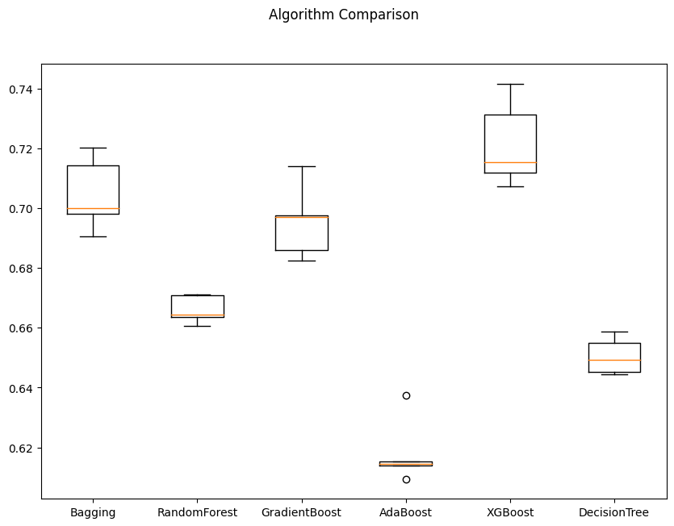

```python
# Plotting boxplots for CV scores of all models defined above
fig = plt.figure(figsize=(10, 7))

fig.suptitle("Algorithm Comparison")
ax = fig.add_subplot(111)

plt.boxplot(results1)
ax.set_xticklabels(names)

plt.show()
```

- With the original data, XGBoost has the best performance on the training set as well as on validation set, followed by Bagging and GBM.

### Model Building with Oversampled data

```python
# Synthetic Minority Over Sampling Technique

print("Before Oversampling, counts of label 'Yes': {}".format(sum(y_train == 1)))
print("Before Oversampling, counts of label 'No': {} \n".format(sum(y_train == 0)))

sm = SMOTE(sampling_strategy=1, k_neighbors=5, random_state=1)
X_train_over, y_train_over = sm.fit_resample(X_train, y_train)

print("After Oversampling, counts of label 'Yes': {}".format(sum(y_train_over == 1)))
print("After Oversampling, counts of label 'No': {} \n".format(sum(y_train_over == 0)))

print("After Oversampling, the shape of train_X: {}".format(X_train_over.shape))
print("After Oversampling, the shape of train_y: {} \n".format(y_train_over.shape))
```

```
Before Oversampling, counts of label 'Yes': 2800
Before Oversampling, counts of label 'No': 30084

After Oversampling, counts of label 'Yes': 30084
After Oversampling, counts of label 'No': 30084

After Oversampling, the shape of train_X: (60168, 52)
After Oversampling, the shape of train_y: (60168,)
```

```python
models = []  # Empty list to store all the models

# Appending models into the list
models.append(("Bagging", BaggingClassifier(random_state=1)))
models.append(("RandomForest", RandomForestClassifier(random_state=1)))
models.append(("GradientBoost", GradientBoostingClassifier(random_state=1)))
models.append(("AdaBoost", AdaBoostClassifier(random_state=1)))
models.append(("XGBoost", XGBClassifier(random_state=1, eval_metric="logloss")))
models.append(("DecisionTree", DecisionTreeClassifier(random_state=1)))

results1 = []  # Empty list to store all model's CV scores
names = []  # Empty list to store name of the models

# Looping through all models to get the mean cross validated score
print("\n" "Cross-Validation Cost:" "\n")

for name, model in models:
    kfold = StratifiedKFold(
        n_splits=5, shuffle=True, random_state=1
    )  # Setting number of splits equal to 5
    cv_result = cross_val_score(estimator=model, X=X_train_over, y=y_train_over, scoring="f1_macro", cv=kfold)
    results1.append(cv_result)
    names.append(name)
    print("{}: {}".format(name, cv_result.mean()))

print("\n" "Validation Performance:" "\n")

for name, model in models:
    model.fit(X_train_over, y_train_over)
    scores = f1_score(y_val, model.predict(X_val))
    print("{}: {}".format(name, scores))
```

```
Cross-Validation Cost:

Bagging: 0.9432537064207025
RandomForest: 0.953601586773084
GradientBoost: 0.881161477265713
AdaBoost: 0.8769535552297489
XGBoost: 0.9403803454810822
DecisionTree: 0.9196644300877225

Validation Performance:

Bagging: 0.33792690233672856
RandomForest: 0.36351441985244803
GradientBoost: 0.3269230769230769
AdaBoost: 0.24168694241686944
XGBoost: 0.42296072507552873
DecisionTree: 0.31210762331838565
```

- With the Over-Sampled data, XGBoost has the best performance on validation set, followed by RandomForest, Bagging and GBM.

### Model Building with Undersampled data

```python
# Random undersampler for under sampling the data
rus = RandomUnderSampler(random_state=1, sampling_strategy=1)
X_train_un, y_train_un = rus.fit_resample(X_train, y_train)
```

```python
print("Before Under Sampling, counts of label 'Yes': {}".format(sum(y_train == 1)))
print("Before Under Sampling, counts of label 'No': {} \n".format(sum(y_train == 0)))

print("After Under Sampling, counts of label 'Yes': {}".format(sum(y_train_un == 1)))
print("After Under Sampling, counts of label 'No': {} \n".format(sum(y_train_un == 0)))

print("After Under Sampling, the shape of train_X: {}".format(X_train_un.shape))
print("After Under Sampling, the shape of train_y: {} \n".format(y_train_un.shape))
```

```
Before Under Sampling, counts of label 'Yes': 2800
Before Under Sampling, counts of label 'No': 30084

After Under Sampling, counts of label 'Yes': 2800
After Under Sampling, counts of label 'No': 2800

After Under Sampling, the shape of train_X: (5600, 52)
After Under Sampling, the shape of train_y: (5600,)
```

```python
models = []  # Empty list to store all the models

# Appending models into the list
models.append(("Bagging", BaggingClassifier(random_state=1)))
models.append(("RandomForest", RandomForestClassifier(random_state=1)))
models.append(("GradientBoost", GradientBoostingClassifier(random_state=1)))
models.append(("AdaBoost", AdaBoostClassifier(random_state=1)))
models.append(("XGBoost", XGBClassifier(random_state=1, eval_metric="logloss")))
models.append(("DecisionTree", DecisionTreeClassifier(random_state=1)))

results1 = []  # Empty list to store all model's CV scores
names = []  # Empty list to store name of the models

# Looping through all models to get the mean cross validated score
print("\n" "Cross-Validation Cost:" "\n")

for name, model in models:
    kfold = StratifiedKFold(
        n_splits=5, shuffle=True, random_state=1
    )  # Setting number of splits equal to 5
    cv_result = cross_val_score(estimator=model, X=X_train_un, y=y_train_un, scoring="f1_macro", cv=kfold)
    results1.append(cv_result)
    names.append(name)
    print("{}: {}".format(name, cv_result.mean()))

print("\n" "Validation Performance:" "\n")

for name, model in models:
    model.fit(X_train_un, y_train_un)
    scores = f1_score(y_val, model.predict(X_val))
    print("{}: {}".format(name, scores))
```

```
Cross-Validation Cost:

Bagging: 0.6868289717494849
RandomForest: 0.7071832081615916
GradientBoost: 0.7140936054357813
AdaBoost: 0.6967737064243286
XGBoost: 0.7022529473121151
DecisionTree: 0.6490172376760739

Validation Performance:

Bagging: 0.28972200969140527
RandomForest: 0.3078055964653903
GradientBoost: 0.35756263532322924
AdaBoost: 0.30702598652550533
XGBoost: 0.3132774815943133
DecisionTree: 0.23295344794282402
```

### HyperparameterTuning

#### Sample Parameter Grids

**Hyperparameter tuning can take a long time to run, so to avoid that time complexity - you can use the following grids, wherever required.**

- For Gradient Boosting:

```
param_grid = {
    "init": [AdaBoostClassifier(random_state=1),DecisionTreeClassifier(random_state=1)],
    "n_estimators": np.arange(75,150,25),
    "learning_rate": [0.1, 0.01, 0.2, 0.05, 1],
    "subsample":[0.5,0.7,1],
    "max_features":[0.5,0.7,1],
}
```

- For Adaboost:

```
param_grid = {
     "n_estimators": np.arange(10, 110, 10),
     "learning_rate": [0.1, 0.01, 0.2, 0.05, 1],
     "base_estimator": [
         DecisionTreeClassifier(max_depth=1, random_state=1),
         DecisionTreeClassifier(max_depth=2, random_state=1),
         DecisionTreeClassifier(max_depth=3, random_state=1),
    ]
}
```

- For Bagging Classifier:

```
param_grid = {
    'max_samples': [0.8,0.9,1],
    'max_features': [0.7,0.8,0.9],
    'n_estimators' : [30,50,70],
}
```

- For Random Forest:

```
param_grid = {
    "n_estimators": [200,250,300],
    "min_samples_leaf": np.arange(1, 4),
    "max_features": [np.arange(0.3, 0.6, 0.1),'sqrt'],
    "max_samples": np.arange(0.4, 0.7, 0.1)
}
```

- For Decision Trees:

```
param_grid = {
    'max_depth': np.arange(2,6),
    'min_samples_leaf': [1, 4, 7],
    'max_leaf_nodes' : [10, 15],
    'min_impurity_decrease': [0.0001,0.001]
}
```

- For XGBoost:

```
param_grid={
   'n_estimators':np.arange(50,300,50),
   'scale_pos_weight':[0,1,2,5,10],
   'learning_rate':[0.01,0.1,0.2,0.05],
   'gamma':[0,1,3,5],
   'subsample':[0.7,0.8,0.9,1]
}
```

#### Tuning Gradient Boosting using original data

```python
%%time

#defining model
Model = GradientBoostingClassifier(random_state=1)

#Parameter grid to pass in RandomSearchCV
param_grid = {
    "init": [AdaBoostClassifier(random_state=1),DecisionTreeClassifier(random_state=1)],
    "n_estimators": np.arange(75,150,25),
    "learning_rate": [0.1, 0.01, 0.2, 0.05, 1],
    "subsample":[0.5,0.7,1],
    "max_features":[0.5,0.7,1],
}

# Type of scoring used to compare parameter combinations
scorer = 'f1_macro'

#Calling RandomizedSearchCV
randomized_cv = RandomizedSearchCV(estimator=Model, param_distributions=param_grid, n_iter=50, scoring=scorer, cv=5, random_state=1, n_jobs = -1)

#Fitting parameters in RandomizedSearchCV
randomized_cv.fit(X_train,y_train)

print("Best parameters are {} with CV score={}:" .format(randomized_cv.best_params_,randomized_cv.best_score_))
```

```
Best parameters are {'subsample': 0.7, 'n_estimators': 125, 'max_features': 0.7, 'learning_rate': 0.2, 'init': AdaBoostClassifier(random_state=1)} with CV score=0.7170649777245176:
CPU times: user 12.3 s, sys: 1.48 s, total: 13.8 s
Wall time: 9min 33s
```

```python
tuned_gbm1 = GradientBoostingClassifier(
    max_features=0.7,
    init=AdaBoostClassifier(random_state=1),
    random_state=1,
    learning_rate=0.2,
    n_estimators=125,
    subsample=0.7,
)

tuned_gbm1.fit(X_train, y_train)
```

```
GradientBoostingClassifier(init=AdaBoostClassifier(random_state=1),
                           learning_rate=0.2, max_features=0.7,
                           n_estimators=125, random_state=1, subsample=0.7)
```

```python
# Checking model's performance on training set
gbm1_train = model_performance_classification_sklearn(tuned_gbm1, X_train, y_train)
gbm1_train
```

|  | Accuracy | Recall | Precision | F1 |
| --- | --- | --- | --- | --- |
| 0 | 0.941 | 0.329 | 0.954 | 0.489 |

```python
# Checking model's performance on validation set
gbm1_val = model_performance_classification_sklearn(tuned_gbm1, X_val, y_val)
gbm1_val
```

|  | Accuracy | Recall | Precision | F1 |
| --- | --- | --- | --- | --- |
| 0 | 0.939 | 0.316 | 0.922 | 0.470 |

#### Tuning Gradient Boosting using undersampled data

```python
%%time

#Creating pipeline
Model = GradientBoostingClassifier(random_state=1)

#Parameter grid to pass in RandomSearchCV
param_grid = {
    "init": [AdaBoostClassifier(random_state=1),DecisionTreeClassifier(random_state=1)],
    "n_estimators": np.arange(75,150,25),
    "learning_rate": [0.1, 0.01, 0.2, 0.05, 1],
    "subsample":[0.5,0.7,1],
    "max_features":[0.5,0.7,1],
}

# Type of scoring used to compare parameter combinations
scorer = 'f1_macro'

#Calling RandomizedSearchCV
randomized_cv = RandomizedSearchCV(estimator=Model, param_distributions=param_grid, n_iter=50, scoring=scorer, cv=5, random_state=1, n_jobs = -1)

#Fitting parameters in RandomizedSearchCV
randomized_cv.fit(X_train_un,y_train_un)

print("Best parameters are {} with CV score={}:" .format(randomized_cv.best_params_,randomized_cv.best_score_))
```

```
Best parameters are {'subsample': 0.7, 'n_estimators': 125, 'max_features': 0.7, 'learning_rate': 0.2, 'init': AdaBoostClassifier(random_state=1)} with CV score=0.7152220120792887:
CPU times: user 3.66 s, sys: 445 ms, total: 4.1 s
Wall time: 1min 58s
```

```python
# Creating new pipeline with best parameters
tuned_gbm2 = GradientBoostingClassifier(
    max_features=0.7,
    init=AdaBoostClassifier(random_state=1),
    random_state=1,
    learning_rate=0.2,
    n_estimators=125,
    subsample=0.7,
)

tuned_gbm2.fit(X_train_un, y_train_un)
```

```
GradientBoostingClassifier(init=AdaBoostClassifier(random_state=1),
                           learning_rate=0.2, max_features=0.7,
                           n_estimators=125, random_state=1, subsample=0.7)
```

```python
# Checking model's performance on training set
gbm2_train = model_performance_classification_sklearn(tuned_gbm2, X_train_un, y_train_un)
gbm2_train
```

|  | Accuracy | Recall | Precision | F1 |
| --- | --- | --- | --- | --- |
| 0 | 0.769 | 0.718 | 0.800 | 0.756 |

```python
# Checking model's performance on validation set
gbm2_val = model_performance_classification_sklearn(tuned_gbm2, X_val, y_val)
gbm2_val
```

|  | Accuracy | Recall | Precision | F1 |
| --- | --- | --- | --- | --- |
| 0 | 0.775 | 0.673 | 0.225 | 0.338 |

#### Tuning XGBoost Model using original data

```python
%%time

#Creating pipeline
Model = XGBClassifier(random_state=1, eval_metric='logloss')

#Parameter grid to pass in RandomSearchCV
param_grid={
   'n_estimators':np.arange(50,300,50),
   'scale_pos_weight':[0,1,2,5,10],
   'learning_rate':[0.01,0.1,0.2,0.05],
   'gamma':[0,1,3,5],
   'subsample':[0.7,0.8,0.9,1]
}

# Type of scoring used to compare parameter combinations
scorer = 'f1_macro'

#Calling RandomizedSearchCV
randomized_cv = RandomizedSearchCV(estimator=Model, param_distributions=param_grid, n_iter=50, scoring=scorer, cv=5, random_state=1, n_jobs= -1)

#Fitting parameters in RandomizedSearchCV
randomized_cv.fit(X_train,y_train)

print("Best parameters are {} with CV score={}:" .format(randomized_cv.best_params_,randomized_cv.best_score_))
```

```
Best parameters are {'subsample': 0.7, 'scale_pos_weight': 2, 'n_estimators': 100, 'learning_rate': 0.1, 'gamma': 1} with CV score=0.7258409159552788:
CPU times: user 4.15 s, sys: 663 ms, total: 4.82 s
Wall time: 2min 57s
```

```python
tuned_xgb1 = XGBClassifier(
    random_state=1,
    eval_metric='logloss',
    subsample=0.7,
    scale_pos_weight=2,
    n_estimators=100,
    learning_rate=0.1,
    gamma=1,
)

tuned_xgb1.fit(X_train, y_train)
```

```
XGBClassifier(base_score=None, booster=None, callbacks=None,
              colsample_bylevel=None, colsample_bynode=None,
              colsample_bytree=None, device=None, early_stopping_rounds=None,
              enable_categorical=False, eval_metric='logloss',
              feature_types=None, gamma=1, grow_policy=None,
              importance_type=None, interaction_constraints=None,
              learning_rate=0.1, max_bin=None, max_cat_threshold=None,
              max_cat_to_onehot=None, max_delta_step=None, max_depth=None,
              max_leaves=None, min_child_weight=None, missing=nan,
              monotone_constraints=None, multi_strategy=None, n_estimators=100,
              n_jobs=None, num_parallel_tree=None, random_state=1, ...)
```

```python
# Checking model's performance on training set
xgb1_train = model_performance_classification_sklearn(tuned_xgb1, X_train, y_train)
xgb1_train
```

|  | Accuracy | Recall | Precision | F1 |
| --- | --- | --- | --- | --- |
| 0 | 0.943 | 0.375 | 0.903 | 0.530 |

```python
# Checking model's performance on validation set
xgb1_val = model_performance_classification_sklearn(tuned_xgb1, X_val, y_val)
xgb1_val
```

|  | Accuracy | Recall | Precision | F1 |
| --- | --- | --- | --- | --- |
| 0 | 0.939 | 0.346 | 0.846 | 0.491 |